# Client Report - [Project 4]

- Show All Code
- Hide All Code

Course DS 250

Author

[Joseph Kazmierski]

## Predictive Models

*Using models to predict data is a very important part of data science. It can be used for anything from risk management, as in when you are trying to predict what the future might look like for a specific metric, to finding missing data that was lost due to unknown reasons. For this report, it was the latter. In this report, I used classification models to predict missing data from before 1980s concerning houses in Denver. It is really interesting to see how different features of homes can show hints to the date that they were built.*

**Read and format project data**

```python
# Include and execute your code here
dwellings_ml = pd.read_csv('https://github.com/byuidatascience/data4dwellings/raw/master/data-raw/dwellings_ml/dwellings_ml.csv')
```

## What Exactly Might Hint Towards the Date That a House was Built?

**Create 2-3 charts that evaluate potential relationships between the home variables and before1980. Explain what you learn from the charts that could help a machine learning algorithm.**

*One thing that will have a large impact on the machine learning results is the quality rating of the home. As you can see from the below graph, before 1980, the proportion of homes that were rated C quality is much higher than after the year 1980. This will have a big part in the machine learning process.*

```python
# Melt the DataFrame to transform it into long format
melted_df = pd.melt(dwellings_ml, id_vars=['yrbuilt'], value_vars=['quality_A', 'quality_B', 'quality_C', 'quality_D', 'quality_X'],
                     var_name='Quality', value_name='Rating')

# Calculate the count of ratings for each quality and year
rating_counts = melted_df.groupby(['yrbuilt', 'Quality']).sum().reset_index()

# Create a bar chart using Plotly Express
fig = px.bar(rating_counts, x='yrbuilt', y='Rating', color='Quality',
              labels={'Rating': 'Number of Ratings', 'yrbuilt': 'Year Built'},
              title='Number of Ratings for Each Quality Over Time')
fig.show()
```

[interactive chart not shown]

*Another variable that might have an affect on the year a home was built is square footage of homes. I know that there is historically a pattern of houses becoming bigger with the passage of time, so this might be a helpful factor in building a maching learning model.*

```python
subset_sqreftage = dwellings_ml.filter(regex = 'yrbuilt|livearea')
ave_area = subset_sqreftage.groupby('yrbuilt')['livearea'].mean().reset_index()

fig2 = px.scatter(ave_area,
                    x = 'yrbuilt',
                    y = 'livearea',
                    title = 'Average Square Footage by Year Built',
                    labels = {'liveare': 'Average Square Footage', 'yrbuilt': 'Year Built'}
)
fig2
```

[interactive chart not shown]

_The plot displays a low point in the graph around the year 1950, which might be a helpful indicator of characterizing houses as before 1980. There is a trend upward from there, so this could be helpful.

## Using Specific Features to Make a Predictive Model

**Build a classification model labeling houses as being built “before 1980” or “during or after 1980”. Your goal is to reach or exceed 90% accuracy. Explain your final model choice (algorithm, tuning parameters, etc) and describe what other models you tried.**

*Using this simple classification model, I was able to get 92 percent accuracy using a test size of .34. I used Random Forest to improve predictive performance. Some of the features that I found most helpful was the liveable square footage, the price, and the number of stories. I put all of these into my classifier.*

```python
#Filter for the coloumns that are most useful
wanted_columns = ['arcstyle_ONE-STORY', 'livearea', 'numbaths', 'tasp', 'netprice', 'sprice', 'stories', 'gartype_Att', 'basement', 'quality_C', 'arcstyle_TWO-STORY', 'abstrprd', 'quality_B', 'numbdrm']


## Filtering out most of the useless coloumns, wasn't worth it
# X_pred = dwellings_ml.drop(dwellings_ml.filter(regex = 'before1980|yrbuilt|parcel|quality_A|condition_Good|gartype_None|gartype_ATT/Det|arcstu;e_TRI-LEVEL|arcstyle_TRIE-LEVEL WITH BASEMENT|arcstyle_THREE-STORY|gartype_Det|condition_VGood|arcstyle_TWO AND HALF-STORY|quality_D|quality_X|condition_Fair|condition_Excel|gartype_CP|gartype_att/CP|gartype_det/CP|arcstyle_SPLIT LEVEL|arcstyle_CONVERSIONS').columns, axis = 1)

X_pred = dwellings_ml[wanted_columns]
y_pred = dwellings_ml['before1980']

# Splitting the data :  Test size specifies the proportion of the dataset that should be allocated to the testing set

X_train, X_test, y_train, y_test = train_test_split(
    X_pred, y_pred, test_size = .34, random_state = 76
)

#Training
clf = RandomForestClassifier()
clf = clf.fit(X_train, y_train)

#Testing
y_pred = clf.predict(X_test)
y_probs = clf.predict_proba(X_test)

print(metrics.classification_report(y_pred, y_test))
```

```
              precision    recall  f1-score   support

           0       0.89      0.89      0.89      2911
           1       0.93      0.94      0.94      4880

    accuracy                           0.92      7791
   macro avg       0.91      0.91      0.91      7791
weighted avg       0.92      0.92      0.92      7791
```

## Why Did I Use Those Specific Features?

**Justify your classification model by discussing the most important features selected by your model. This discussion should include a chart and a description of the features.**

_Before building my classifier, I built this chart that shows me the most important features that can impact my model. Of the most important ones are if the house is one story, the area, the number of bathrooms, the different selling prices, and the number of stories. All of these features played big roles in the building of the classifier. In the beginning of this report, I guessed that the area would have an impact on whether a house could be classified as before 1980, and that is because houses have gotten bigger over time on average.

```python
# This creates a dataframe using the X train coloumns to show which features of the house contributed most to the classification model
df_features = pd.DataFrame(
    {'f_names': X_train.columns,
    'f_values': clf.feature_importances_}).sort_values('f_values', ascending = False)

#Creates a bar chart that shows the significance of each feature
chart = px.bar(df_features.head(25),
    x='f_values',
    y='f_names'
)
chart.update_layout(yaxis={'categoryorder':'total ascending'})
```

[interactive chart not shown]

## How Accurate Did My Model Get?

**Describe the quality of your classification model using 2-3 different evaluation metrics. You also need to explain how to interpret each of the evaluation metrics you use.**

_From the ROC curve below, you can see that the area under the curve is very high, which indicates that my model is a high performance model. The dotted line that you see below shows what the curve would look like if it was strictly guessing, so you can see that the ROC curve that I produced is much more accurate than just guessing.

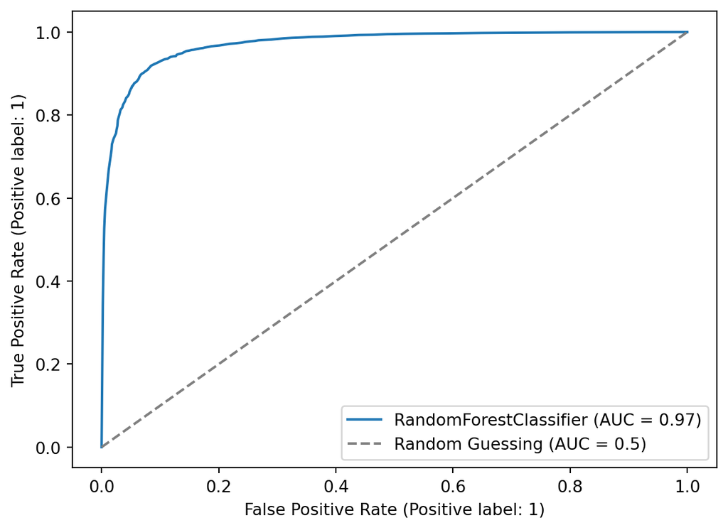

```python
import matplotlib.pyplot as plt

# Set the threshold for predictions to achieve AUC=0.5 (random guessing)
threshold = 0.5

# Predict probabilities for positive class
y_prob = clf.predict_proba(X_test)[:, 1]

# Adjust predictions based on the threshold
y_pred_adjusted = (y_prob > threshold).astype(int)

# Plot the ROC curve with adjusted predictions
roc_display = RocCurveDisplay.from_estimator(clf, X_test, y_test)
roc_display.ax_.plot([0, 1], [0, 1], linestyle='--', color='gray', label='Random Guessing (AUC = 0.5)')
roc_display.ax_.legend()
plt.show()
```

_The ROC Curve from above as well as the data from my classification report show that this classifier is high quality. Under the precision column, the row labeled “0” represents the proportion of instances where the model predicted a negative when it was truly negative. The row labeled “1” represents the proportion of instances where the model predicted a positive when it was truly positive. As you can see, the true negative proportion of 90% and the true positive proportion of .93 are very high, which is another indicator of the accuracy of this classifier.

```python
print(metrics.classification_report(y_pred, y_test))
```

```
              precision    recall  f1-score   support

           0       0.89      0.89      0.89      2911
           1       0.93      0.94      0.94      4880

    accuracy                           0.92      7791
   macro avg       0.91      0.91      0.91      7791
weighted avg       0.92      0.92      0.92      7791
```

Back to top